# Empirical Network Comparison by Clinical Topic

Xinrui Shi

2026-08-28

# Aim and data boundary

This report reproduces the comparison of networks across Clinical Topics using only the 300 empirical networks. Clinical Topic codes are read from the empirical database summary, but no metric value is read from that file. All retained metrics are recomputed during rendering from the saved empirical incidence matrices by `compute_metrics_for_networks()` in `metric_functions.R`.

For this analysis, a Clinical Topic is included in the comparison when it contains at least 25 empirical networks. Each selected Clinical Topic is also compared with the distribution across all 300 empirical networks. The latter comparisons are exploratory because a selected Clinical Topic is a subset of the overall empirical distribution.

# Read and validate empirical inputs

The analysis contains 300 empirical networks and the 16 retained metrics computed by `metric_functions.R`. `N_total_trials` is reported as the number of trials. The number of arms counts trial–treatment edges in the bipartite graph; the number of distinct treatment comparisons counts unique edges in the unipartite treatment projection.

# Clinical Topic labels and eligible Clinical Topics

Empirical Clinical Topics with at least 25 networks

| Clinical Topic code | Number of networks | Full Clinical Topic label | Plot label |
| --- | --- | --- | --- |
| 2 | 49 | 02: Neoplasms | 02 |
| 6 | 29 | 06: Mental, behavioural or neurodevelopmental disorders | 06 |
| 11 | 25 | 11: Diseases of the circulatory system | 11 |
| 13 | 26 | 13: Diseases of the digestive system | 13 |
| 21 | 27 | 21: Symptoms, signs or clinical findings, not elsewhere classified | 21 |

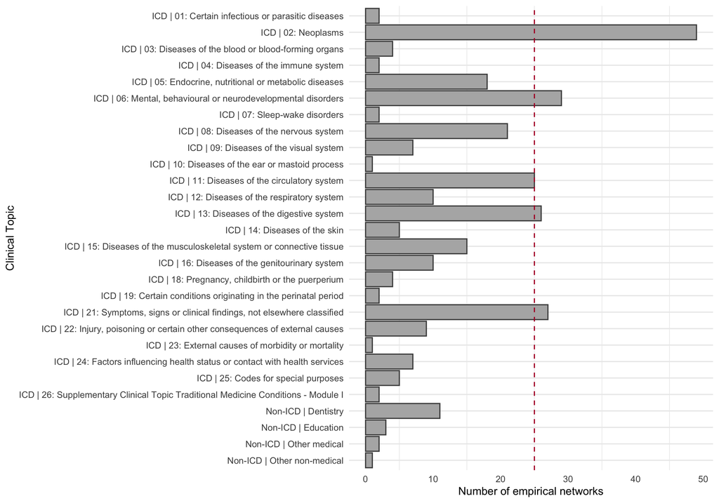

# Trial–treatment dimensions

The grey layer shows the joint $(M,N)$ distribution across all empirical networks. The colored layer identifies the five selected Clinical Topics. Here, $M$ is the number of trials and $N$ is the number of treatments; point area is proportional to the number of networks at the same $(M,N)$ coordinate.

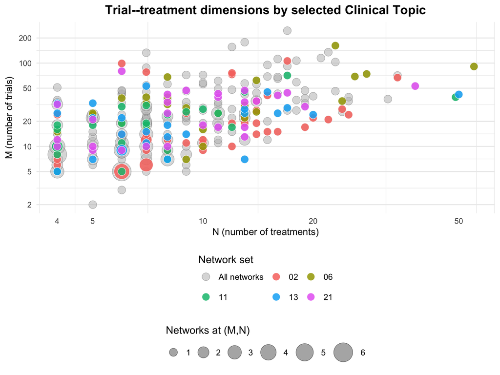

# Summary statistics

The table below reports each metric as the median, with the interquartile range (IQR) in parentheses, for all empirical networks and for each of the five selected Clinical Topics.

Network metrics reported as median (IQR).

| Metric | Network | Overall | 02 | 06 | 11 | 13 | 21 |
| --- | --- | --- | --- | --- | --- | --- | --- |
| **Density** | Unipartite | 0.33 (0.27) | 0.29 (0.13) | 0.33 (0.24) | 0.36 (0.24) | 0.29 (0.22) | 0.29 (0.34) |
|  | Bipartite | 0.26 (0.17) | 0.23 (0.18) | 0.25 (0.16) | 0.33 (0.17) | 0.29 (0.21) | 0.24 (0.19) |
| **Mean degree** | Unipartite (treatments) | 2.42 (1.00) | 2.00 (0.79) | 2.50 (1.25) | 2.00 (1.29) | 2.20 (0.61) | 2.47 (0.61) |
|  | Bipartite (trial) | 2.07 (0.18) | 2.00 (0.12) | 2.07 (0.17) | 2.00 (0.10) | 2.06 (0.21) | 2.06 (0.13) |
|  | Bipartite (treatments) | 4.78 (5.52) | 2.86 (2.25) | 6.33 (5.54) | 5.25 (4.08) | 3.89 (3.84) | 5.20 (4.64) |
| **Clustering coefficient** | Unipartite | 0.28 (0.45) | 0.09 (0.29) | 0.38 (0.34) | 0.11 (0.55) | 0.26 (0.35) | 0.22 (0.42) |
| **Average path length** | Unipartite | 1.74 (0.42) | 1.90 (0.47) | 1.75 (0.46) | 1.71 (0.44) | 1.71 (0.38) | 1.78 (0.56) |
| **Degree assortativity** | Unipartite | -0.64 (0.32) | -0.71 (0.30) | -0.61 (0.28) | -0.68 (0.46) | -0.71 (0.37) | -0.67 (0.14) |
|  | Bipartite | -0.11 (0.14) | -0.13 (0.14) | -0.11 (0.10) | -0.08 (0.25) | -0.08 (0.08) | -0.13 (0.08) |
| **Degree irregularity** | Unipartite | 0.80 (0.92) | 0.86 (0.74) | 0.82 (0.87) | 0.43 (0.61) | 0.91 (0.73) | 1.07 (1.15) |
|  | Bipartite (trial) | 0.02 (0.03) | 0.00 (0.02) | 0.01 (0.03) | 0.00 (0.02) | 0.01 (0.03) | 0.01 (0.02) |
|  | Bipartite (treatments) | 0.86 (0.96) | 0.86 (0.89) | 0.86 (0.93) | 0.44 (0.65) | 0.91 (0.69) | 1.17 (1.31) |
| **Network size** | Treatments | 8.0 (7.0) | 9.0 (8.0) | 9.0 (6.0) | 7.0 (4.0) | 7.0 (7.8) | 9.0 (7.0) |
|  | Trials | 22.0 (27.0) | 14.0 (15.0) | 26.0 (18.0) | 18.0 (16.0) | 22.0 (17.2) | 30.0 (29.0) |
| **Number of edges** | Bipartite (arms) | 45.0 (56.0) | 28.0 (33.0) | 58.0 (38.0) | 36.0 (35.0) | 44.5 (33.5) | 62.0 (58.5) |
|  | Unipartite (distinct comparisons) | 10.0 (12.0) | 9.0 (12.0) | 13.0 (13.0) | 7.0 (7.0) | 7.0 (11.0) | 12.0 (8.5) |

# Statistical comparisons

For each numeric metric, the Kruskal–Wallis test compares the selected Clinical Topics with one another. The Wilcoxon rank-sum tests reproduce the exploratory comparison of each selected Clinical Topic with the overall empirical distribution. Benjamini–Hochberg adjustment is applied across all tests in each family, and the adjusted p-value is the primary inferential result. In this report, adjusted p-values rounded to two decimal places at or below 0.10 are interpreted as evidence of a distributional difference.

Metrics with Benjamini–Hochberg adjusted p-values, rounded to two decimal places, at or below 0.1 across eligible Clinical Topics: Mean treatment degree (Bipartite); Number of trials; Number of arms (bipartite edges); Mean treatment degree (Unipartite); Clustering coefficient (Unipartite).

Clinical Topic–metric comparisons with Benjamini–Hochberg adjusted p-values rounded to two decimals at or below 0.1

| Clinical Topic | Metric | Direction | Clinical Topic median | Overall median | BH-adjusted p |
| --- | --- | --- | --- | --- | --- |
| 02 | Mean treatment degree (Bipartite) | lower | 2.86 | 4.78 | 0.00 |
| 02 | Clustering coefficient (Unipartite) | lower | 0.09 | 0.28 | 0.01 |
| 02 | Mean treatment degree (Unipartite) | lower | 2.00 | 2.42 | 0.01 |
| 02 | Average path length (Unipartite) | higher | 1.90 | 1.74 | 0.03 |
| 02 | Density (Unipartite) | lower | 0.29 | 0.33 | 0.07 |
| 02 | Mean trial degree (Bipartite) | lower | 2.00 | 2.07 | 0.07 |
| 02 | Trial-degree irregularity (Bipartite) | lower | 0.00 | 0.02 | 0.07 |
| 02 | Number of arms (bipartite edges) | lower | 28.00 | 45.00 | 0.07 |
| 02 | Number of trials | lower | 14.00 | 22.00 | 0.08 |

# Metric distributions

Each panel compares the eligible Clinical Topics with the overall empirical distribution. Integer metrics with relatively few values use proportional bar charts; other metrics use a histogram for the overall distribution and frequency polygons for the selected Clinical Topics. Boxplots provide a common direct comparison.

## Density (Unipartite)

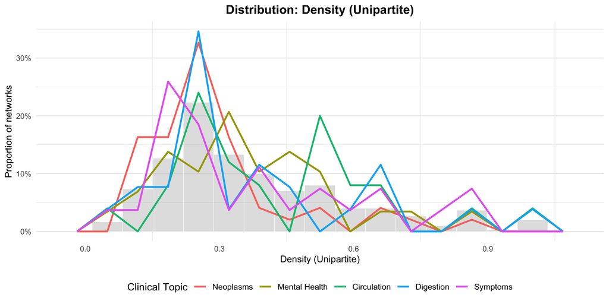

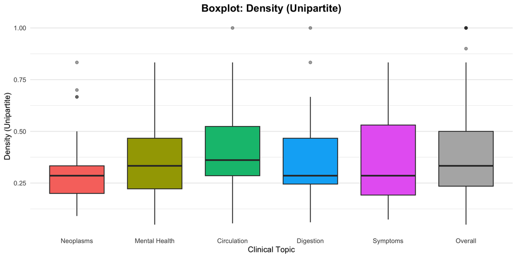

## Density (Bipartite)

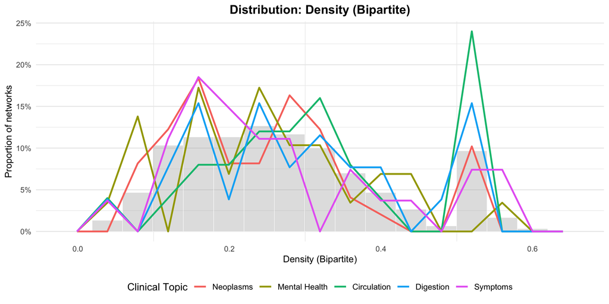

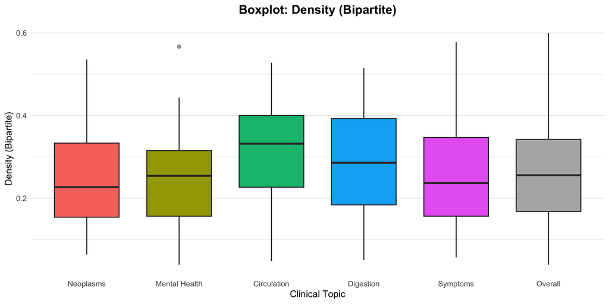

## Mean treatment degree (Unipartite)

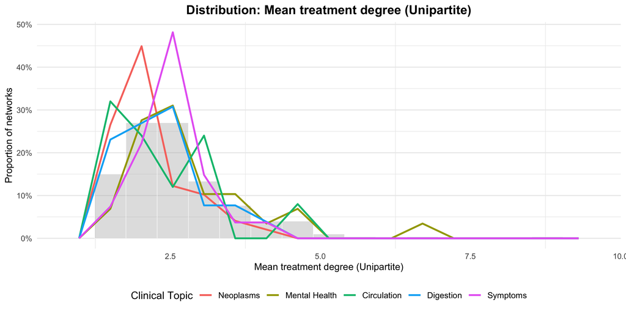

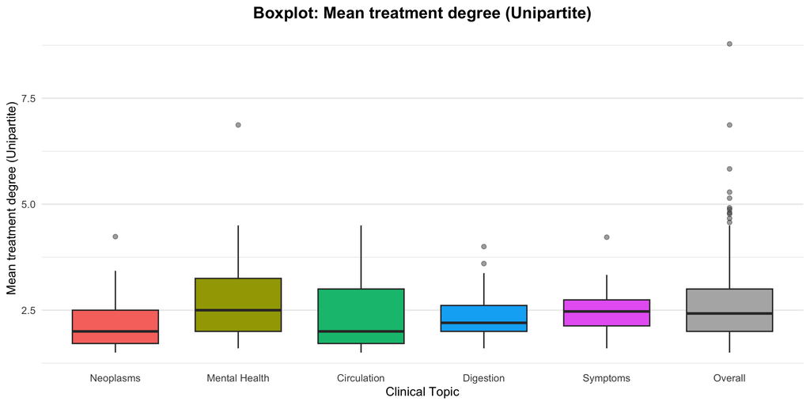

## Mean trial degree (Bipartite)

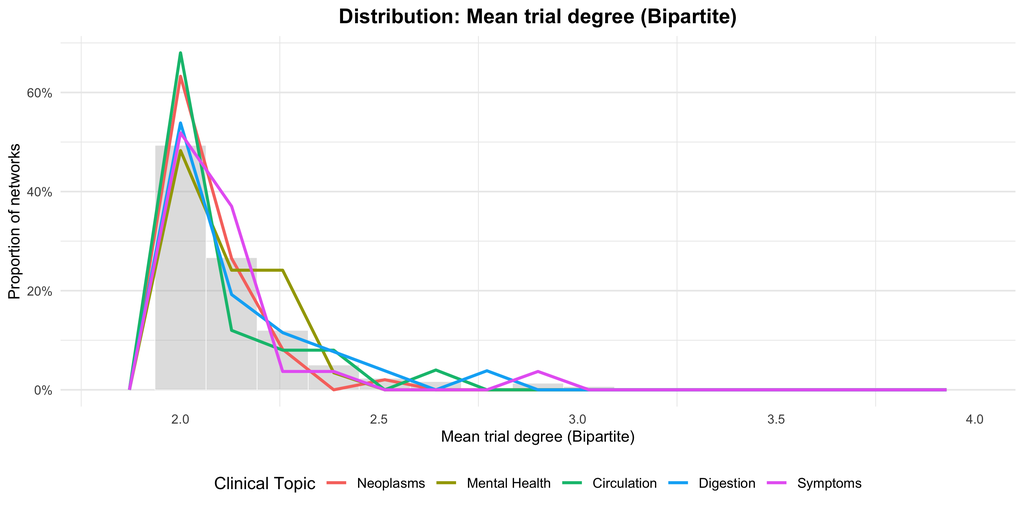

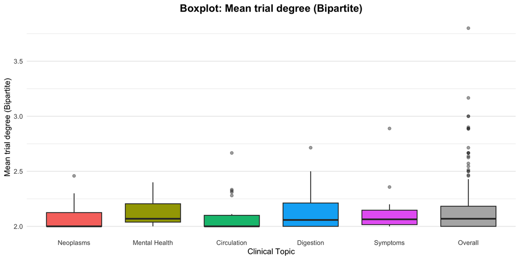

## Mean treatment degree (Bipartite)

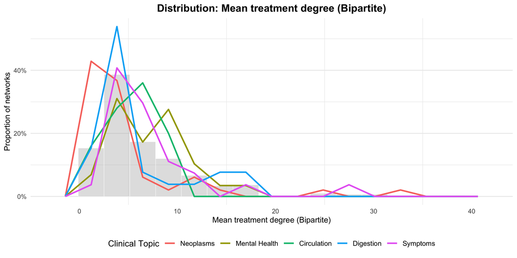

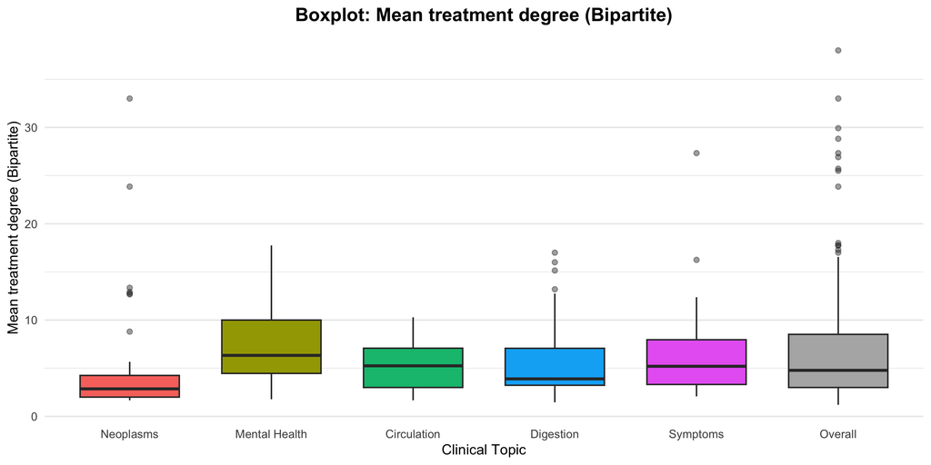

## Average path length (Unipartite)

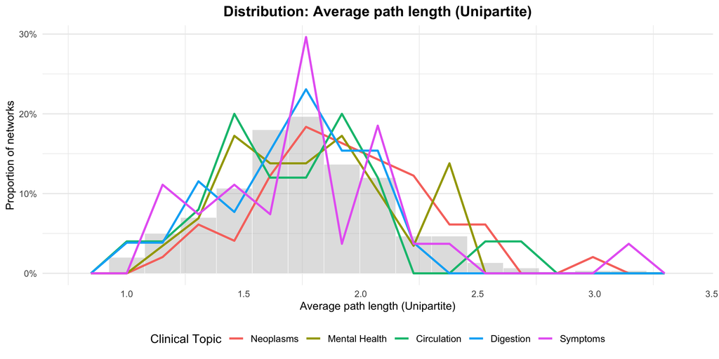

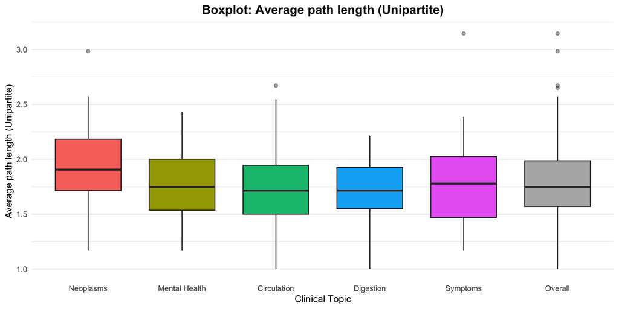

## Clustering coefficient (Unipartite)

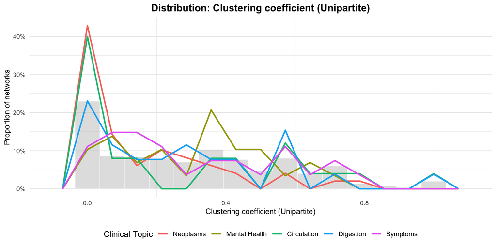

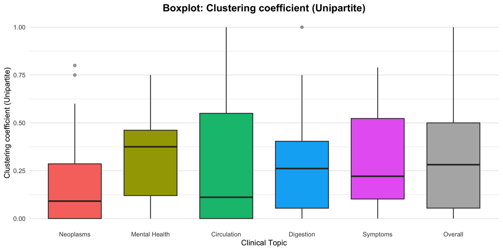

## Degree assortativity (Unipartite)

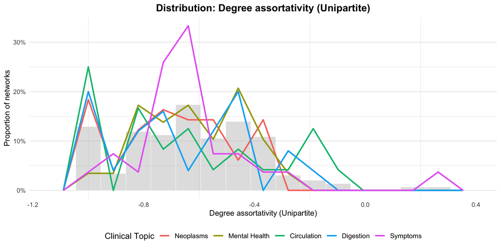

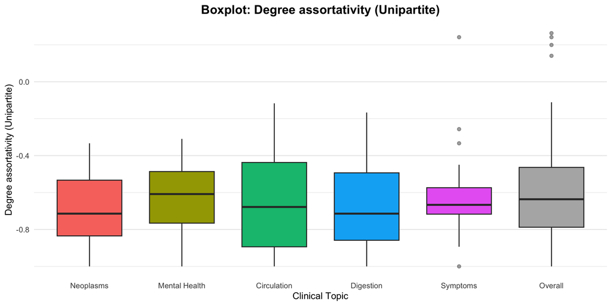

## Degree assortativity (Bipartite)

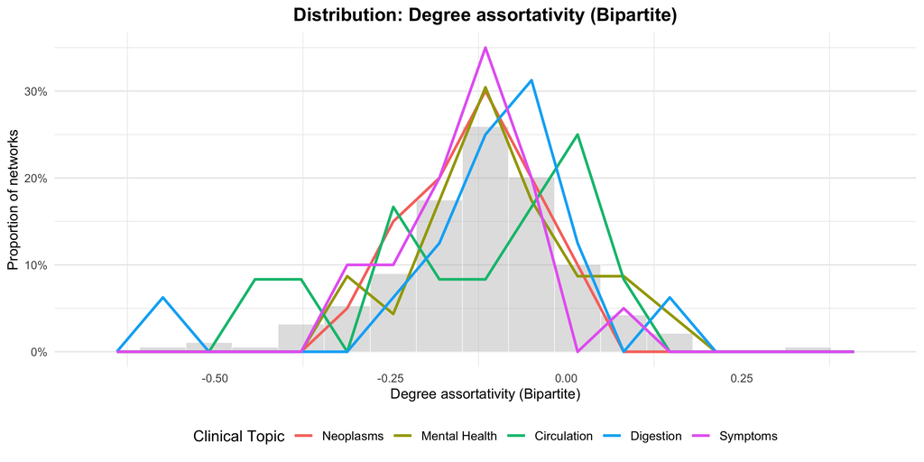

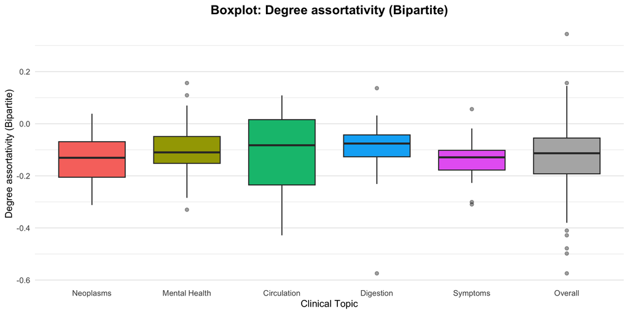

## Degree irregularity (Unipartite)

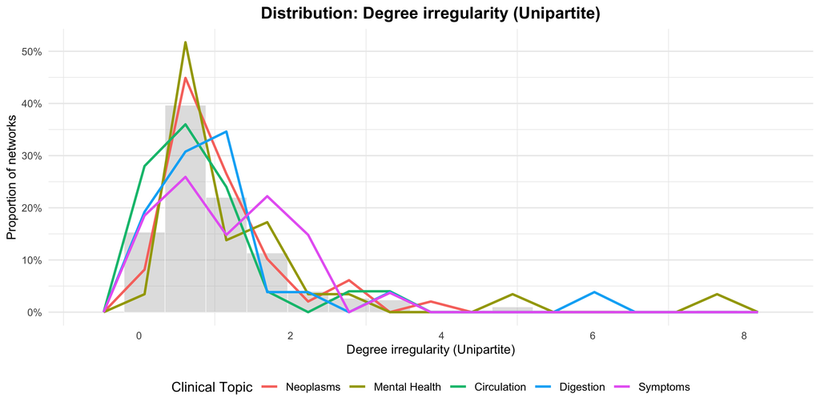

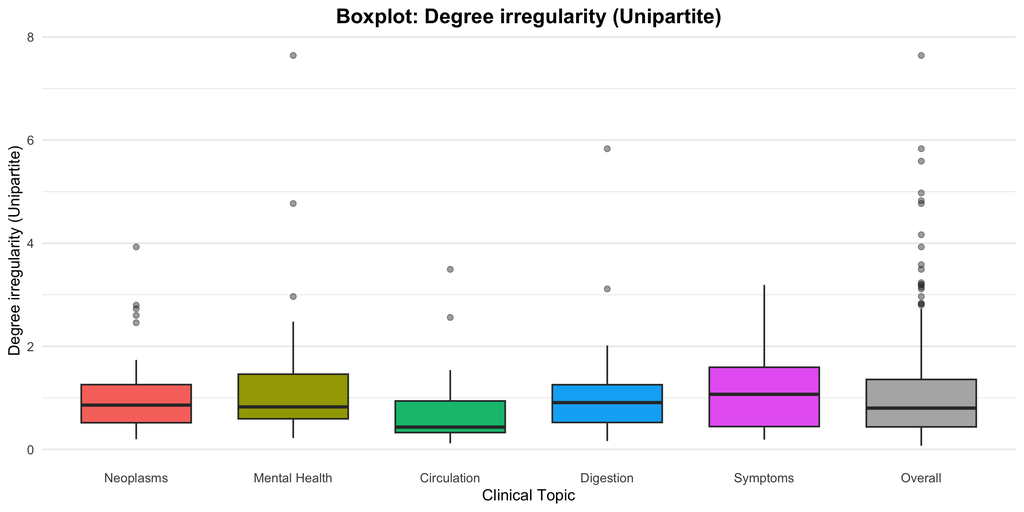

## Trial-degree irregularity (Bipartite)

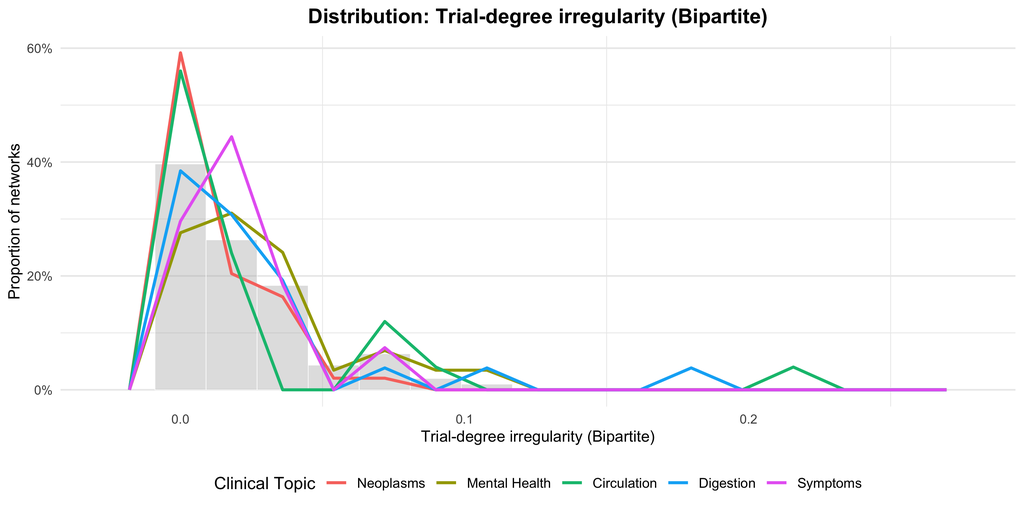

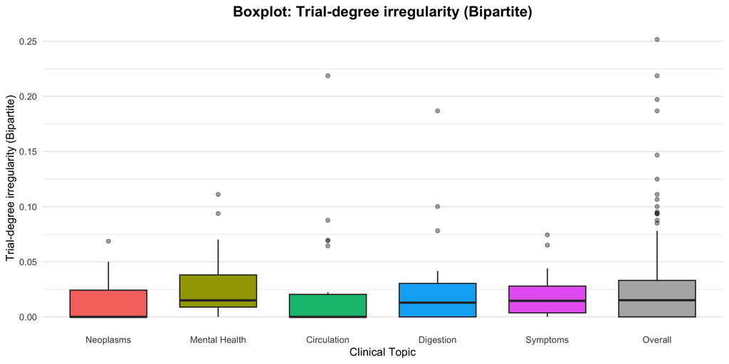

## Treatment-degree irregularity (Bipartite)

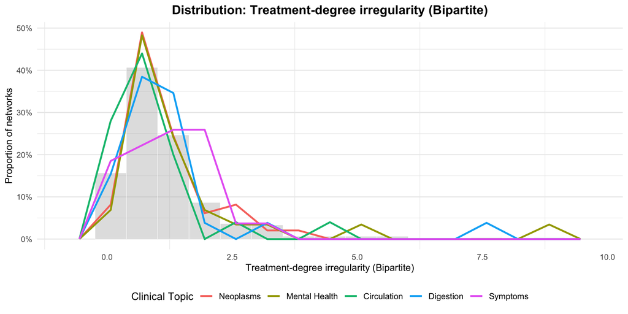

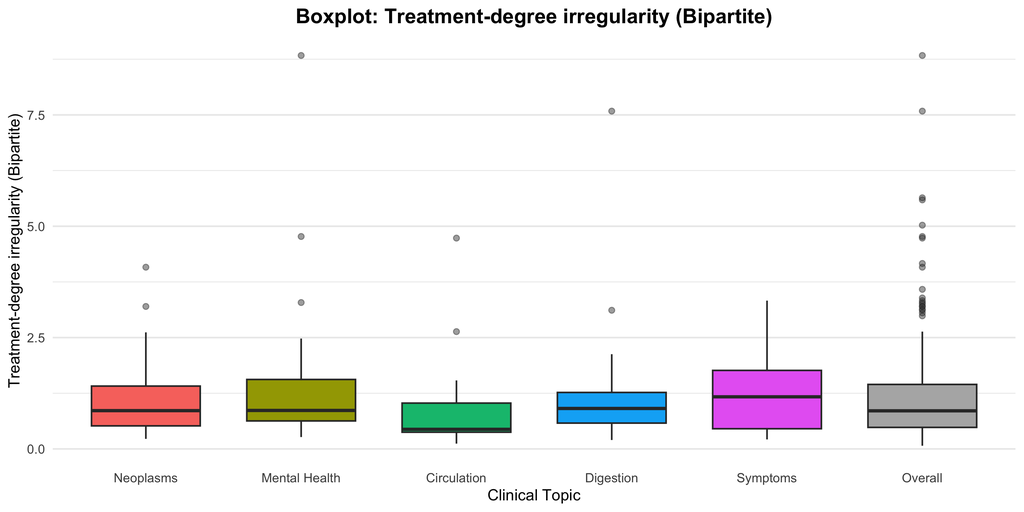

## Number of treatments

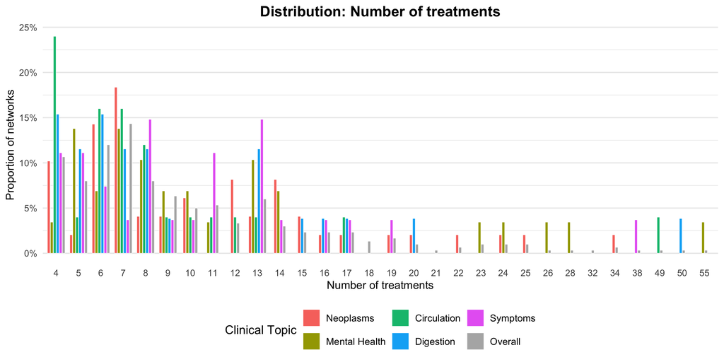

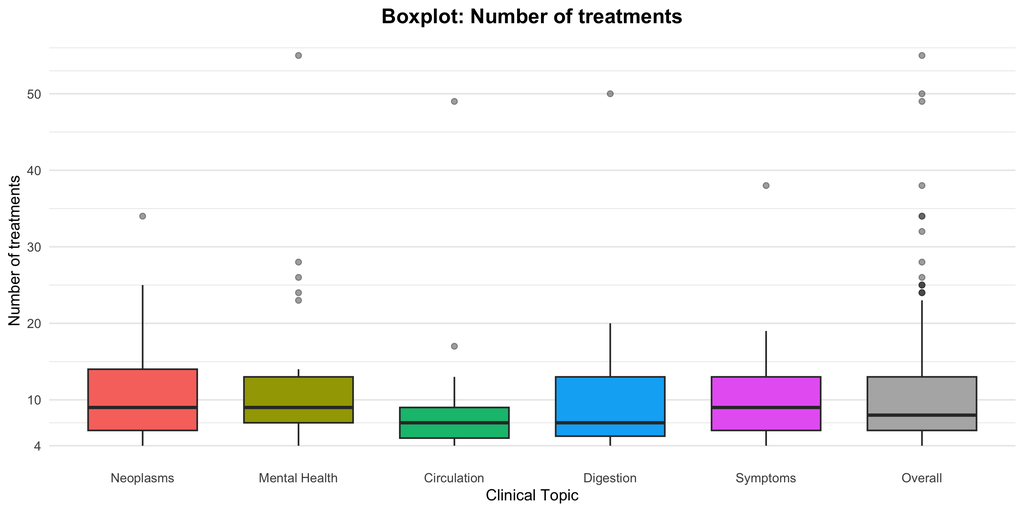

## Number of trials

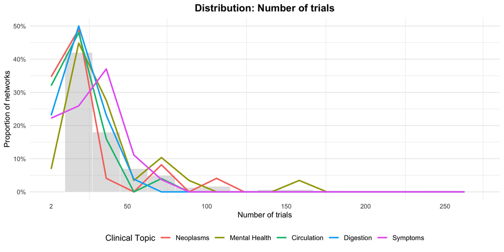

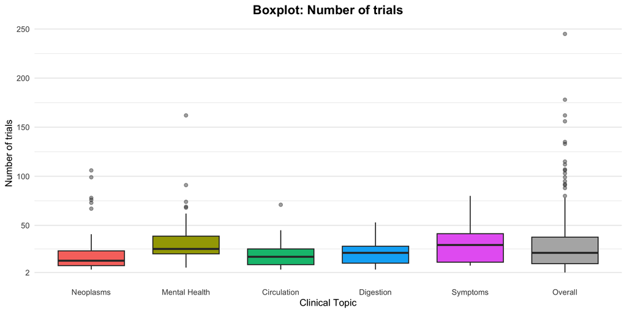

## Number of arms (bipartite edges)

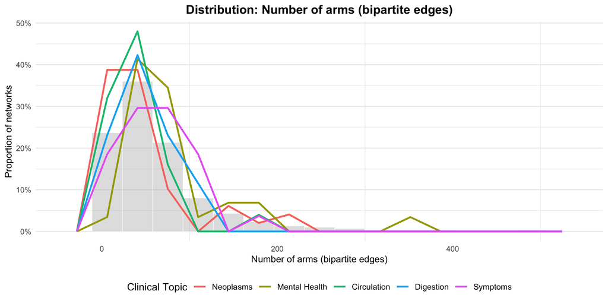

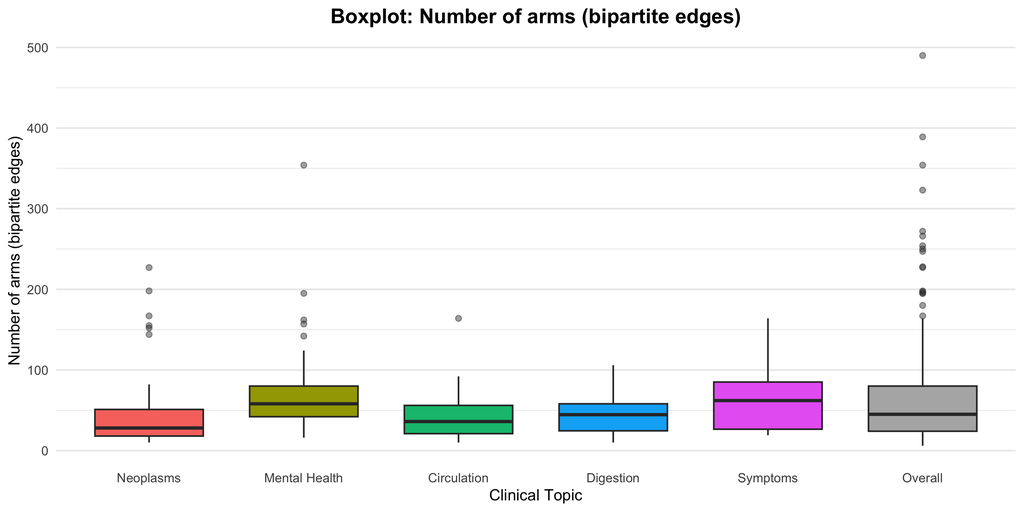